# Distribution Theory & Mathematical Models

STAT 240 - Fall 2025

Robert Sholl

# Distribution Theory

Last stop out of theory-land

## Motivation

**Describe the support of the following random variables:**

$$\begin{array}{|c|c|}
\hline
\text{r.v.} & \text{Description} \\
\hline
T & \text{Time it takes for a drug to enter the blood stream} \\
\hline
U & \text{Probability of landing on 3 on a fair 6-sided dice} \\
\hline
V & \text{Volume of the water in a swimming pool} \\
\hline
W & \text{Proportion of people who get sick at an Aggieville bar}\\
\hline
X & \text{The result of 50 coin flips} \\
\hline
Y & \text{Number of wild boar observed in a 10 acre plot} \\
\hline
\end{array}$$

## Normality

Given:

$$X \sim N(\mu,\sigma^2)$$

- $X$ is continuous
- The support of $X$ is $S_X = (-\infty,\infty)$
- $X$ has a centered mean as well as constant variance
  - Both are finite (a.k.a., they exist)

## Design vs. Modeling

There are *two ways* to approach the application of statistics: Design or modeling

- We can use simplistic modeling if we have a very good study/experimental design
- If our design is flawed we can make up for this with better modeling
- Both can be improved with increased sample sizes

## Modeling

For modeling we have *two options* for getting stronger inference:

- Increase sample size
- Load on assumptions
  - Is the assumption of normality asking much?
  - If $\mu$ is large and $\sigma$ is small we don’t care about the lower bounds

# Tranformation of the response

## Continuous

$$\begin{aligned}
& Y = \{\text{The number of wild boar observed in a 10 acre plot}\} \\
& S_Y = \{0,1,2,...\} \\
\end{aligned}$$

Let $\ell = \ln{(Y)}$

$$S_{\ell} = [0,\infty)$$

## Negative support

$$T = \{\text{The time it takes for a drug to enter the blood stream}\}$$

Let $\tilde T = T + 100$

- Now no matter how small $T$ is, $\tilde T$ won’t cross $0$
- If $\tilde T$ looks bell shaped we can use the normal distribution!

## Symmetry

$$W = \{\text{The proportion of people who get sick at an Aggieville bar}\} \\$$

Say that $W$ was right-skewed:

- Let $Q = \arcsin \sqrt{W}$
- [the arcsine is asinine](https://esajournals.onlinelibrary.wiley.com/doi/10.1890/10-0340.1)

## Symmetry

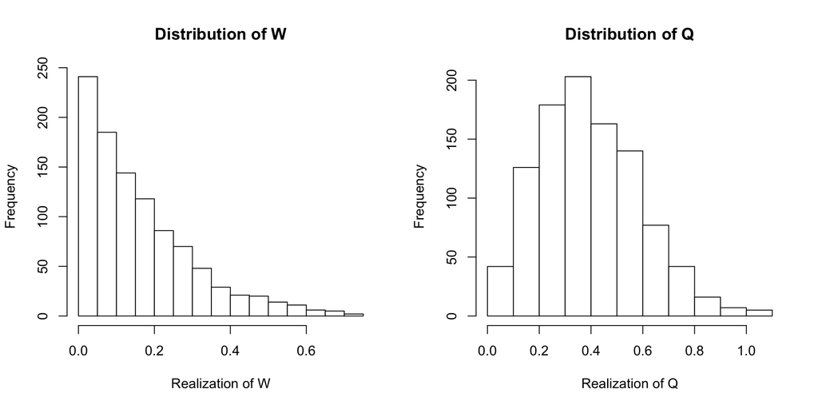

# Other Named Distributions

## Assumptions

- Hand-wavey transformations are useful
  - But they can be uncomfortable
- Let’s look at what we dealt with last class

$$\mu_{\bar x} = \mu \quad , \quad \sigma_{\bar x} = \frac{\sigma}{\sqrt{n}}$$

## Bias vs. Variance

Let $\mu = 10$ and $\sigma = 5$. Show the distribution of $\bar x$ at $n=1$, $n=10$, $n=100$, and $n=1000$.

## Assumptions = Samples?

> What’s a possible explanation for this? Does the opposite relationship make sense?

## Distribution Theory

- In distribution theory we seek to:
  - Formally describe distributions of random variables
  - Determine their moments and other features
  - Put them into practice
  - Locate any useful transformations or cases of the distributions

# Discrete

## Bernoulli

Let $X$ be the result of a **fair** coin toss.

$$X = \begin{cases}
1 & \text{if heads} \\
0 & \text{if tails} \\
\end{cases}$$

$$P(X=x)=
\begin{cases}
0.5 & \text{if }\ x=1 \\
0.5 & \text{if }\ x=0
\end{cases}$$

## Bernoulli

Let $X$ be the result of an **unfair** coin toss.

- We don’t know the probability of heads, let’s label it $p$

$$P(X=x)=
\begin{cases}
p & \text{if }\ x=1 \\
1-p & \text{if }\ x=0
\end{cases}$$

$$X \sim \text{Bern}(p)$$

## Binomial

Let $X$ be the result of $2$ fair coin tosses.

- There are multiple combinations of $X=x$:

$$\begin{array}{|c|c|}
\hline
\text{Flip 1} & \text{Flip 2}\\
\hline
\text{1} & \text{1}\\
\hline
\text{1} & \text{0}\\
\hline
\text{0} & \text{1}\\
\hline
\text{0} & \text{0}\\
\hline
\end{array}$$

## Binomial

Thinking a little differently:

- We have $3$ possible outcomes (if order doesn’t matter)

$$\begin{array}{|c|c|c|c|}
\hline
& 0 & 1 & 2\\
\hline
0 & 1 & 0 & 0 \\
\hline
1 & 1 & 1 & 0 \\
\hline
2 & 1 & 2 & 1 \\
\hline
\end{array}$$

## Binomial

We can represent this with the “choose” function:

$${n \choose x} = \frac{n!}{x!(n-x)!}$$

$\text{where } n!=n\times(n-1)\times (n-2) \times...\times3 \times 2 \times 1$

If the flips are *independent* we can express the probability as:

$$\begin{aligned}
& \text{Success} = p^x \\
& \text{Failure} = (1-p)^{n-x} \\
\end{aligned}$$

## Binomial

Smashing those together:

$$P(X=x)={n \choose x}p^x(1-p)^{n-x}$$

$$X \sim \text{Binom}(n,p)$$

## Binomial

$$\begin{aligned}
& X \sim \text{Binom}(n,p) \\
\\
& \mathbb{E}X = np \\
\\
& \mathbb{V}X=np(1-p) \\
\\
\end{aligned}$$

- What about Bernoulli?

## Poisson

Poisson: the French word for “fish”

$$X \sim \text{Pois}(\lambda)$$

$$\mathbb{E}X=\mathbb{V}X=\lambda$$

## Poisson

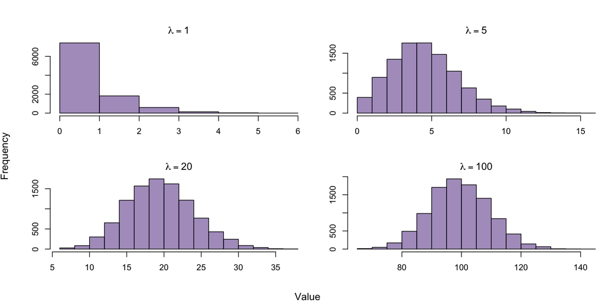

# Continuous

## Uniform

- Before we defined this as a shape
- Imagine now that you can control the *interval* of that uniform bar

$$f(x)=\begin{cases} \frac{1}{b-a} & \text{for }\ a \leq x \leq b \\ 0 & \text{otherwise} \end{cases}$$

$$X\sim \text{Unif}(a,b)$$

## Beta

- For data that takes on values between $0$ and $1$
  - And those values *are not* constant

$$X \sim \text{Beta}(\alpha,\beta)$$

$$\mathbb{E}X=\frac{\alpha}{\alpha+\beta} \quad \quad \mathbb{V}X=\frac{\alpha \beta}{(\alpha+ \beta)^2(\alpha+\beta+1)}$$

## Beta

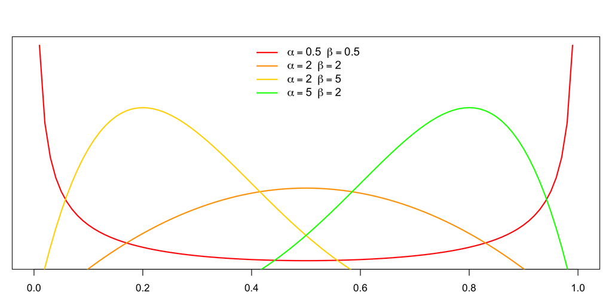

## Mixing Distributions

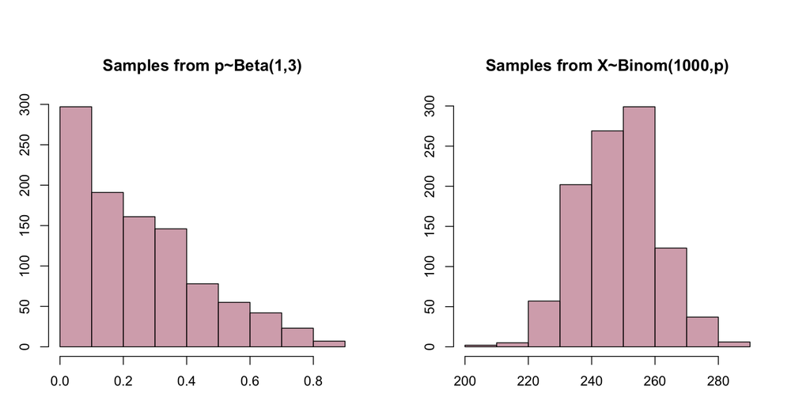

## Time

Is time **discrete** or **continuous**?

- Imagine how you would describe both!
- Now imagine the constraints for both
  - Can time be negative?
  - Can time stretch to infinities?

## Gamma

For **continuous** and **strictly positive** data:

$$X \sim \text{Gamma}(\alpha,\beta)$$

- The expectation and variance of this differ
  - Depends how we parameterize it
  - As such, we won’t discuss those

## Gamma

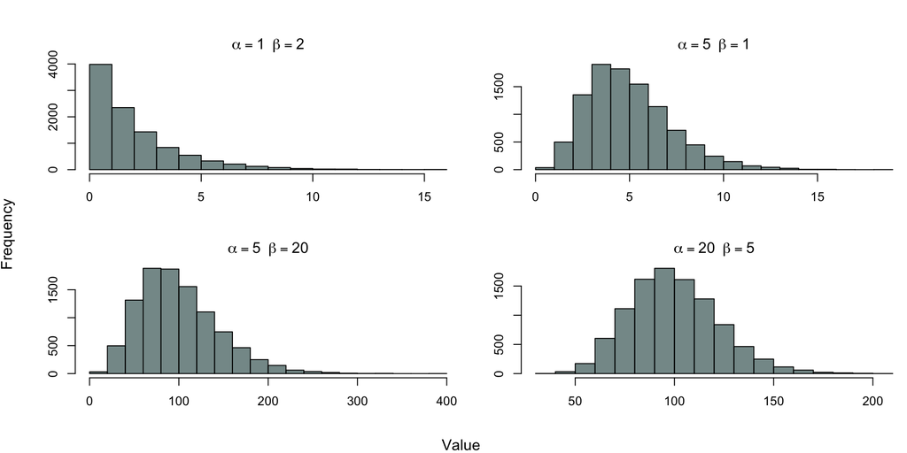

# Mathematical Models

Time to draw lines

## Models

- Any mathematical representation of a process
- Think about model planes:
  - Can we make a very simple one?
  - What about a very complex one?
  - Can they both fly?
  - Is either as good as a real plane?

## Phenomenological Models

Building a model, blind of a process, to better understand a process.

$$y = mx + b$$

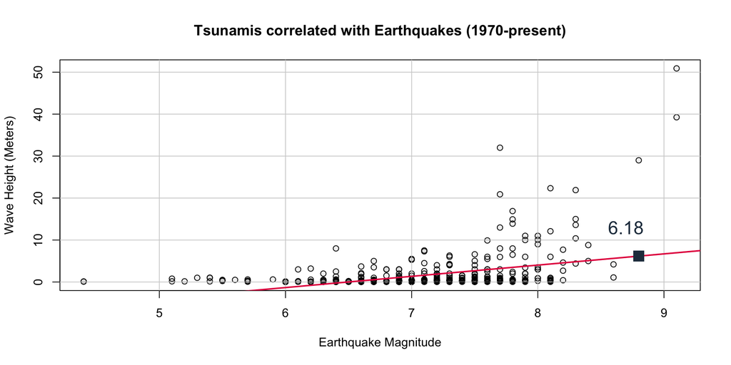

## Mechanistic Models

Building a model using knowledge of a process, to better understand the data.

$$\lambda(t)=\lambda_0e^{\gamma(t-t_0)}$$

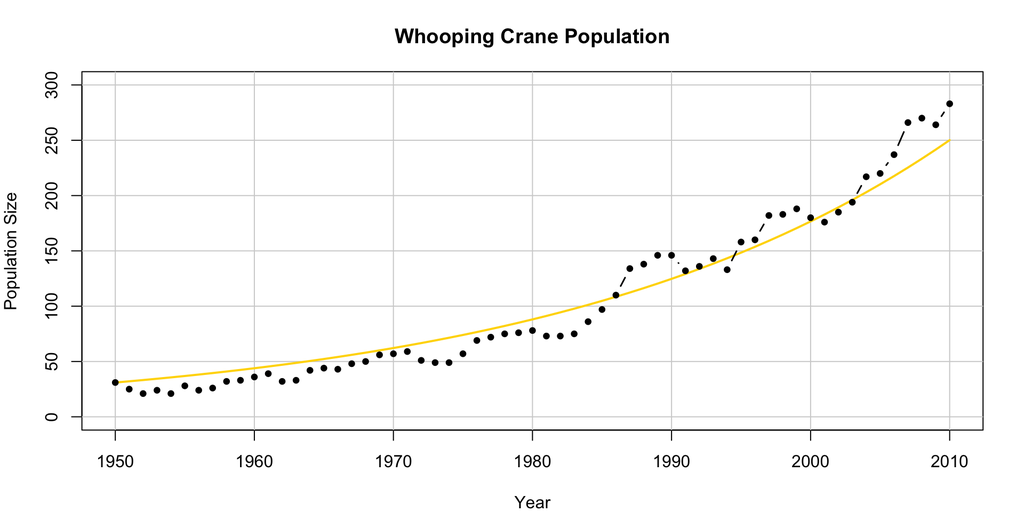

## Linear

Linear *in the parameters*:

$$Y=aX+b$$

$$w=\beta_0+\beta_1x+\beta_2x^2$$

$$P=\mu+\alpha\log(r\times t)$$

$$\boldsymbol \Delta=\boldsymbol \beta \cos(\boldsymbol X)+10$$

## Nonlinear

We did something *nonlinear* to those parameters:

$$Y=a^2X+b$$

$$w=\beta_0+\log(\beta_1)x$$

$$\lambda(t)=\lambda_0e^{\gamma(t-t_0)}$$

## Deterministic

The same inputs **always** result in the same outputs:

$$y = 2x$$

- Let $x=4$
- Let $x=4$ again
- Did you get the same result?

## Probabilistic

There’s some **random element** to the model:

$$y = mx + b + \text{Random Error}$$

- The same input won’t always get the same output
  - This is where we can slap distributions into the mix

## “Solving” models

- **Explicit models**: Input values for the parameters and solve for the output (a.k.a. response)
- **Implicit models**: Solve for the parameters to understand the structure of the model
- We do both in statistics (usually back to back)

$$P(t)=P_0e^{rt}$$

$$y=mx+b$$

## Derived Quantities

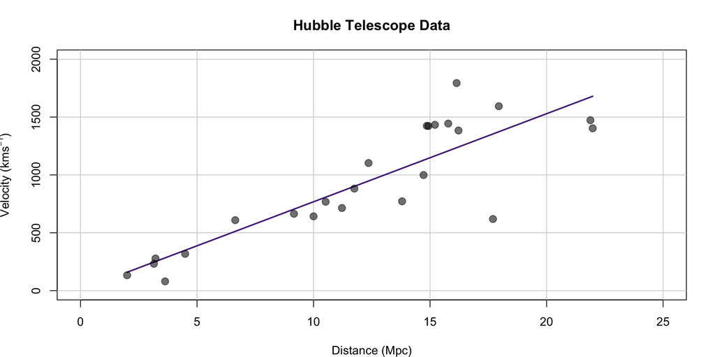

## Final Note

There’s two more “distinctions” of models, specific to statistics:

- Frequentist
  - This is *every* method we learn in this class
- Bayesian
  - This exists, we’ll talk about it a little, not too much
  - STAT 341, STAT 610/611, STAT 768